# FFT_SSVEP_analysis

Christopher

2 7 2024

Modelling of raw [*CSD based*] amplitude values from fft-based data via linear mixed models via standard anova models

```r
library(lme4)
library(readxl)
library(tidyverse)
library(data.table)
library(tidyverse)
library(afex)
library(broom)
library(apa)
library(kableExtra)
library(lmerTest)
library(pbkrtest)
library(effects)
library(visreg)
library(sjPlot)
library(broom.mixed)
library(pander)
library(mediation)
library(multcomp)
library(multcompView)
library(magrittr)
library(multipanelfigure)
library(ggbeeswarm)
library(lsmeans)
library(BayesFactor)
library(ggpubr)
library(gpairs)
library(DescTools)
library(cowplot)
library(ggpol)
library(logspline)

source('C:/Dropboxdata/Dropbox/work/R-statistics/general_functions/RainCloudPlots/tutorial_R/R_rainclouds.R')
source('C:/Dropboxdata/Dropbox/work/R-statistics/general_functions/RainCloudPlots/tutorial_R/R_rainclouds.R')

source('C:/Dropboxdata/Dropbox/work/R-statistics/examples/Bayesian_rank-based_hypothesis_testing/rankBasedCommonFunctions.R')
source('C:/Dropboxdata/Dropbox/work/R-statistics/examples/Bayesian_rank-based_hypothesis_testing/rankSumSampler.R') # Wilcoxon rank sum function
source('C:/Dropboxdata/Dropbox/work/R-statistics/examples/Bayesian_rank-based_hypothesis_testing/signRankSampler.R') # Wilcoxon signed-rank function
source('C:/Dropboxdata/Dropbox/work/R-statistics/examples/Bayesian_rank-based_hypothesis_testing/spearmanSampler.R')# Spearman's rho function




# broad cluster
# CSD based normalized to pre-cue baseline in %
#
DATAPath = "data_in/FFT_Amp_data_largeclust_06-14-2024_13-19.csv"
t_baseline = c(-1000, 0)


# broad cluster | smaller central cluster
# CSD based normalized to pre-cue baseline in %
#
# DATAPath = "data_in/FFT_Amp_data_largeclust_06-24-2024_15-43.csv"
# t_baseline = c(-1000, 0)


# broad cluster | smaller central cluster
# CSD based normalized to pre-cue baseline in %
# for changed experiment starting with participant 22: isoluminant stimuli and lower flicker frequencies
#
DATAPath = "data_in/FFT_Amp_data_largeclust_allsubs_08-30-2024_11-21.csv"
t_baseline = c(-1000, 0)


# broad cluster | larger central cluster |
# peri: not correct!
# CSD based normalized to pre-cue baseline in %
# for changed experiment starting with participant 22: isoluminant stimuli and lower flicker frequencies
#
# DATAPath = "data_in/FFT_Amp_data_pericenter_allsubs_07-02-2024_11-46.csv"
# t_baseline = c(-1000, 0)
#
# broad cluster | very broad central cluster
# CSD based normalized to pre-cue baseline in %
# for changed experiment starting with participant 22: isoluminant stimuli and lower flicker frequencies
# #
# DATAPath = "data_in/FFT_Amp_data_largecenterclust_allsubs_09-11-2024_14-45.csv"
# t_baseline = c(-1000, 0)



#!!!!!!! relevant
# broad cluster | larger central cluster as in Tango study | peri both clusters but smaller
# CSD based normalized to pre-cue baseline in %
# for changed experiment starting with participant 22: isoluminant stimuli and lower flicker frequencies
DATAPath = "data_in/FFT_Amp_data_CenterTangoStudyPeriSmall_05-23-2025_11-56.csv"
t_baseline = c(-1000, 0)

# broad cluster | larger central cluster as in Tango study | peri only center
# DATAPath = "data_in/FFT_Amp_data_TangoStudyPeriOnlyCenter_11-25-2024_14-17.csv"
# t_baseline = c(-1000, 0)

# # broad cluster | larger central cluster as in Tango study | peri only lateral | in this study shows gain for attended
# DATAPath = "data_in/FFT_Amp_data_TangoStudyPeriOnlyLateral_11-25-2024_14-17.csv"
# t_baseline = c(-1000, 0)


#!!!!!!!


# replication relevant
# broad cluster | larger central cluster as in Tango study | peri both clusters as in Tango study
# CSD based normalized to pre-cue baseline in %
# for changed experiment starting with participant 22: isoluminant stimuli and lower flicker frequencies
# DATAPath = "data_in/FFT_Amp_data_TangoStudy_05-23-2025_11-53.csv"
# t_baseline = c(-1000, 0)


# exploratory | induced removed as in FShiftAlpha
# broad cluster | larger central cluster as in Tango study | peri both clusters but smaller
# CSD based normalized to pre-cue baseline in %
# for changed experiment starting with participant 22: isoluminant stimuli and lower flicker frequencies
# DATAPath = "data_in/FFT_Amp_data_CenterTangoStudyPeriSmall_indremov08-15-2025_13-50.csv"
# t_baseline = c(-1000, 0)



options(scipen=1, digits=7)
```

## Prepare data

1. Read in data:
- data_in/FFT_Amp_data_CenterTangoStudyPeriSmall_05-23-2025_11-56.csv
- with pre-cue [-1000, 0] ms

```r
sub_sample = c(0)
# sub_sample = as.factor(c(26,30, 31,37, 38)) # no ssvep people discarded
sub_sample = as.factor(c(42)) # low trial number


# read in data
DataIn <- read.csv(DATAPath, sep = ";") %>%
  mutate(subjects = as.factor(subjects))%>%
  filter(!subjects %in% sub_sample)
head(DataIn)
str(DataIn)
```

[output not shown]

## Illustrate SSVEP Data

### 1b Illustrate Data as is | center RDKs

plot differently

```r
#evoked raw#### for center

dat2plot <- DataIn %>%
  filter(RDK_position2=="center") %>%
  group_by(subjects, time, RDK_isattended, RDK_colorlum)%>%
  summarise(amplitude_evoked=mean(amplitude_evoked), modulation_evoked=mean(modulation_evoked))%>%
  filter(time=='[0.5 1.5] ', RDK_colorlum == 'isolum__to_bckgrd')
```

```
## can override using the `.groups` argument.
```

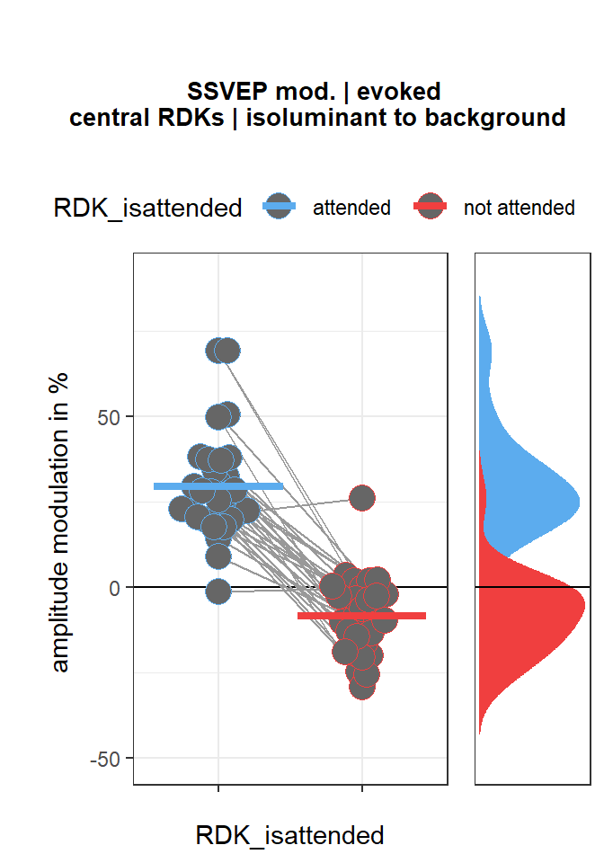

```r
# set limits
yax_limits <- c( min(dat2plot$modulation_evoked), max(dat2plot$modulation_evoked))
yax_limits <- round(yax_limits + c(-1, 1)*diff(yax_limits)*0.1)
yax_limits <- yax_limits + c(-1, 1)*diff(yax_limits)*0.1


theme_set(theme_bw())
plot1 <- ggplot(dat2plot, aes(x = RDK_isattended, y = modulation_evoked, fill = RDK_isattended)) +
  geom_hline(yintercept=0, show.legend = FALSE) +
  geom_line(aes(group = interaction(subjects,time)),colour = "grey60",alpha = 1,size =0.5) +
  geom_beeswarm(aes(color = RDK_isattended, x = RDK_isattended,
                    group = RDK_isattended), cex=3, size = 5,alpha=1,fill="grey40",shape=21)+
  # geom_point(aes(color = RDK_isattended, x = interaction(time,RDK_isattended),
  #                   group = RDK_isattended), size = 4,alpha=0.4)+
  stat_summary(fun.y=mean, aes(ymin=..y.., ymax=..y.., color =RDK_isattended), geom='errorbar', width=0.9, size=1.5) +
  scale_x_discrete("RDK_isattended", breaks=waiver(), labels = rep(c(""),1,2)) +
  # theme(legend.position="bottom") +
  ylab(expression(paste("amplitude modulation in %")))+
  scale_fill_manual(values=c("steelblue2", "#F03F3F"))+
  scale_color_manual(values=c("steelblue2", "#F03F3F"))+
  #  scale_fill_manual(values=c("#193A3D", "#F03F3F"))+
  # scale_color_manual(values=c("#193A3D", "#F03F3F"))+
  # scale_fill_manual(values=c(rgb2hex(0.0, 153.0, 204.0),rgb2hex(0.0, 77, 102.0)))+
  # scale_color_manual(values=c(rgb2hex(0.0, 153.0, 204.0),rgb2hex(0.0, 77, 102.0)))+
  theme(legend.position="none")+
  # scale_y_continuous(limits=c(-60, 140))
  scale_y_continuous(limits=yax_limits)


plot2 <- ggplot(dat2plot, aes(y = modulation_evoked, fill = RDK_isattended, x = 1)) +
  geom_flat_violin(aes(fill = RDK_isattended),position = position_nudge(x = .1, y = 0),
                   adjust = 1.3, trim = FALSE, alpha = 1, colour = NA)+
  geom_hline(yintercept=0, show.legend = FALSE) +
  # scale_fill_manual(values=c("#193A3D", "#F03F3F"))+
  # scale_color_manual(values=c("#193A3D", "#F03F3F"))+
  scale_fill_manual(values=c("steelblue2", "#F03F3F"))+
  scale_color_manual(values=c("steelblue2", "#F03F3F"))+
  # scale_fill_manual(values=c(rgb2hex(0.0, 153.0, 204.0),rgb2hex(0.0, 77, 102.0)))+
  # scale_color_manual(values=c(rgb2hex(0.0, 153.0, 204.0),rgb2hex(0.0, 77, 102.0)))+
  theme(axis.title.y=element_blank(),
        axis.text.y=element_blank(),
        axis.ticks.y=element_blank())+
  theme(axis.title.x=element_blank(),
        axis.text.x=element_blank(),
        axis.ticks.x=element_blank())+
  theme(panel.grid.major = element_blank(), panel.grid.minor = element_blank())+
  # scale_y_continuous(limits=c(-60, 140))
  scale_y_continuous(limits=yax_limits)



# cowplot::plot_grid(plot1, plot2, plot3, ncol = 3,labels = "AUTO")
plotttitle <- ggdraw() +
  draw_label("SSVEP mod. | evoked \ncentral RDKs | isoluminant to background", fontface='bold', size = 10)
plotplots <- ggarrange(plot1, plot2,ncol = 2,common.legend = TRUE,align = "h", widths=c(3,1))

savefig <- multi_panel_figure(columns = 1, rows = 1, panel_label_type = "none", width = 3.5, height = 5, unit = "in")
saveplot <- ggarrange(plotttitle, plotplots, nrow = 2, heights=c(0.2, 1))

savefig %<>%
  fill_panel(saveplot, column = 1, row = 1)
savefig
```

```r
# save_multi_panel_figure(savefig, "figures/FFT_BeeSwarm_Mod_ALPHA_COL_34subs.eps")



dat2plot <- DataIn %>%
  filter(RDK_position2=="center") %>%
  group_by(subjects, time, RDK_isattended, RDK_colorlum)%>%
  summarise(amplitude_evoked=mean(amplitude_evoked), modulation_evoked=mean(modulation_evoked), subtraction_evoked = mean(subtraction_evoked))%>%
  filter(time=='[0.5 1.5] ', RDK_colorlum == 'isolum__to_bckgrd')
```

```
## can override using the `.groups` argument.
```

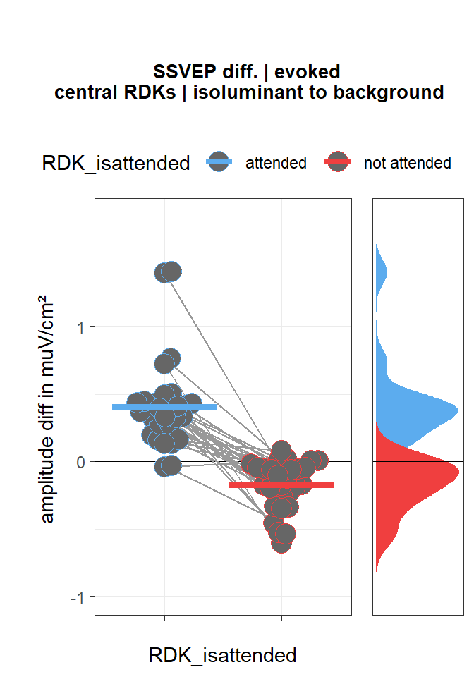

```r
# set limits
yax_limits <- c( min(dat2plot$subtraction_evoked), max(dat2plot$subtraction_evoked))
# yax_limits <- round(yax_limits + c(-1, 1)*diff(yax_limits)*0.1)
yax_limits <- yax_limits + c(-1, 1)*diff(yax_limits)*0.2
# # yax_limits <- c(-27, 15)

theme_set(theme_bw())
plot1 <- ggplot(dat2plot, aes(x = RDK_isattended, y = subtraction_evoked, fill = RDK_isattended)) +
  geom_hline(yintercept=0, show.legend = FALSE) +
  geom_line(aes(group = interaction(subjects,time)),colour = "grey60",alpha = 1,size =0.5) +
  geom_beeswarm(aes(color = RDK_isattended, x = RDK_isattended,
                    group = RDK_isattended), cex=3, size = 5,alpha=1,fill="grey40",shape=21)+
  # geom_point(aes(color = RDK_isattended, x = interaction(time,RDK_isattended),
  #                   group = RDK_isattended), size = 4,alpha=0.4)+
  stat_summary(fun.y=mean, aes(ymin=..y.., ymax=..y.., color =RDK_isattended), geom='errorbar', width=0.9, size=1.5) +
  scale_x_discrete("RDK_isattended", breaks=waiver(), labels = rep(c(""),1,2)) +
  # theme(legend.position="bottom") +
  ylab(expression(paste("amplitude diff in muV/cm²")))+
  scale_fill_manual(values=c("steelblue2", "#F03F3F"))+
  scale_color_manual(values=c("steelblue2", "#F03F3F"))+
  #  scale_fill_manual(values=c("#193A3D", "#F03F3F"))+
  # scale_color_manual(values=c("#193A3D", "#F03F3F"))+
  # scale_fill_manual(values=c(rgb2hex(0.0, 153.0, 204.0),rgb2hex(0.0, 77, 102.0)))+
  # scale_color_manual(values=c(rgb2hex(0.0, 153.0, 204.0),rgb2hex(0.0, 77, 102.0)))+
  theme(legend.position="none")+
  # scale_y_continuous(limits=c(-60, 140))
  scale_y_continuous(limits=yax_limits)


plot2 <- ggplot(dat2plot, aes(y = subtraction_evoked, fill = RDK_isattended, x = 1)) +
  geom_flat_violin(aes(fill = RDK_isattended),position = position_nudge(x = .1, y = 0),
                   adjust = 1.3, trim = FALSE, alpha = 1, colour = NA)+
  geom_hline(yintercept=0, show.legend = FALSE) +
  # scale_fill_manual(values=c("#193A3D", "#F03F3F"))+
  # scale_color_manual(values=c("#193A3D", "#F03F3F"))+
  scale_fill_manual(values=c("steelblue2", "#F03F3F"))+
  scale_color_manual(values=c("steelblue2", "#F03F3F"))+
  # scale_fill_manual(values=c(rgb2hex(0.0, 153.0, 204.0),rgb2hex(0.0, 77, 102.0)))+
  # scale_color_manual(values=c(rgb2hex(0.0, 153.0, 204.0),rgb2hex(0.0, 77, 102.0)))+
  theme(axis.title.y=element_blank(),
        axis.text.y=element_blank(),
        axis.ticks.y=element_blank())+
  theme(axis.title.x=element_blank(),
        axis.text.x=element_blank(),
        axis.ticks.x=element_blank())+
  theme(panel.grid.major = element_blank(), panel.grid.minor = element_blank())+
  # scale_y_continuous(limits=c(-60, 140))
  scale_y_continuous(limits=yax_limits)



# cowplot::plot_grid(plot1, plot2, plot3, ncol = 3,labels = "AUTO")
plotttitle <- ggdraw() +
  draw_label("SSVEP diff. | evoked \ncentral RDKs | isoluminant to background", fontface='bold', size = 10)
plotplots <- ggarrange(plot1, plot2,ncol = 2,common.legend = TRUE,align = "h", widths=c(3,1))

savefig <- multi_panel_figure(columns = 1, rows = 1, panel_label_type = "none", width = 3.5, height = 5, unit = "in")
saveplot <- ggarrange(plotttitle, plotplots, nrow = 2, heights=c(0.2, 1))

savefig %<>%
  fill_panel(saveplot, column = 1, row = 1)
savefig
```

```r
# save_multi_panel_figure(savefig, "figures/FFT_BeeSwarm_Mod_ALPHA_COL_34subs.eps")
```

### 1c Illustrate Data as is | center RDKs separate for experimental conditions | only isoluminant

plot differently

```r
#evoked raw#### for center

# set overall limits?
dat2plot <- DataIn %>%
  filter(RDK_position2=="center", RDK_colorlum=="isolum__to_bckgrd") %>%
  mutate(condition_label = case_when(
    condition %in% c(1,2) ~ "peri_AttUnatt",
    condition %in% c(3,4) ~ "peri_AttIrrel",
    condition %in% c(5,6) ~ "peri_UnattIrrel"
  ))%>%
  group_by(subjects, time, RDK_isattended, condition_label)%>%
  summarise(amplitude_evoked=mean(amplitude_evoked), modulation_evoked=mean(modulation_evoked))%>%
  filter(time=='[0.5 1.5] ')
```

```
## can override using the `.groups` argument.
```

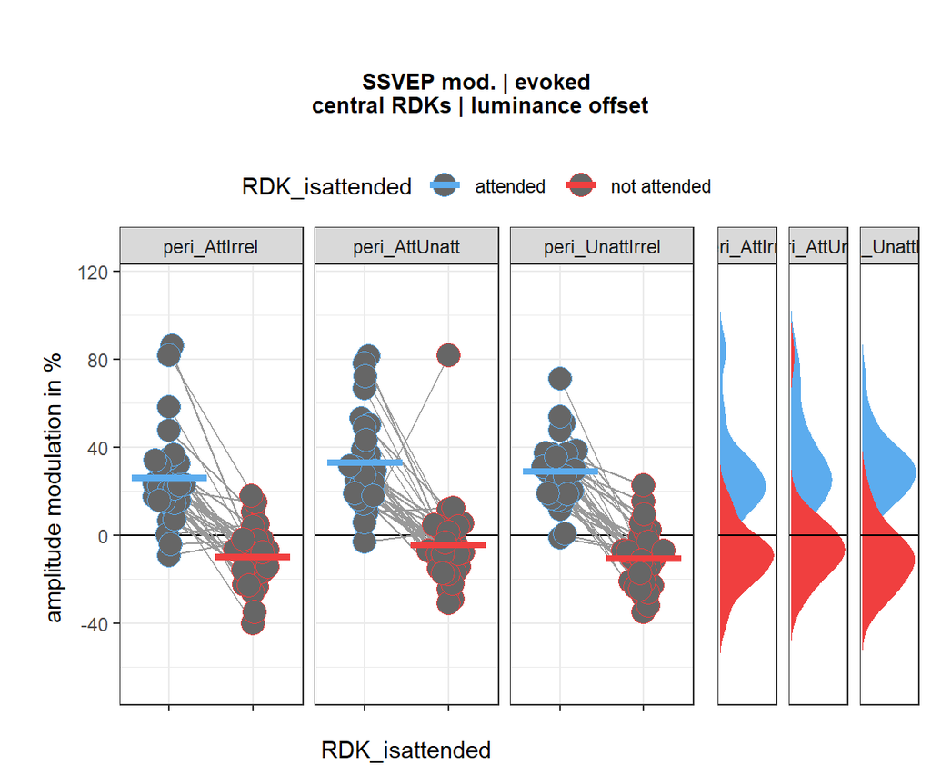

```r
# set limits
yax_limits <- c( min(dat2plot$modulation_evoked), max(dat2plot$modulation_evoked))
yax_limits <- round(yax_limits + c(-1, 1)*diff(yax_limits)*0.1)
yax_limits <- yax_limits + c(-1, 1)*diff(yax_limits)*0.1
# # yax_limits <- c(-27, 15)

theme_set(theme_bw())
plot1 <- ggplot(dat2plot, aes(x = RDK_isattended, y = modulation_evoked, fill = RDK_isattended)) +
  geom_hline(yintercept=0, show.legend = FALSE) +
  geom_line(aes(group = interaction(subjects,time)),colour = "grey60",alpha = 1,size =0.5) +
  geom_beeswarm(aes(color = RDK_isattended, x = RDK_isattended,
                    group = RDK_isattended), cex=3, size = 5,alpha=1,fill="grey40",shape=21)+
  # geom_point(aes(color = RDK_isattended, x = interaction(time,RDK_isattended),
  #                   group = RDK_isattended), size = 4,alpha=0.4)+
  stat_summary(fun.y=mean, aes(ymin=..y.., ymax=..y.., color =RDK_isattended), geom='errorbar', width=0.9, size=1.5) +
  scale_x_discrete("RDK_isattended", breaks=waiver(), labels = rep(c(""),1,2)) +
  facet_grid(.~condition_label)+
  # theme(legend.position="bottom") +
  ylab(expression(paste("amplitude modulation in %")))+
  scale_fill_manual(values=c("steelblue2", "#F03F3F"))+
  scale_color_manual(values=c("steelblue2", "#F03F3F"))+
  #  scale_fill_manual(values=c("#193A3D", "#F03F3F"))+
  # scale_color_manual(values=c("#193A3D", "#F03F3F"))+
  # scale_fill_manual(values=c(rgb2hex(0.0, 153.0, 204.0),rgb2hex(0.0, 77, 102.0)))+
  # scale_color_manual(values=c(rgb2hex(0.0, 153.0, 204.0),rgb2hex(0.0, 77, 102.0)))+
  theme(legend.position="none")+
  # scale_y_continuous(limits=c(-60, 140))
  scale_y_continuous(limits=yax_limits)


plot2 <- ggplot(dat2plot, aes(y = modulation_evoked, fill = RDK_isattended, x = 1)) +
  geom_flat_violin(aes(fill = RDK_isattended),position = position_nudge(x = .1, y = 0),
                   adjust = 1.3, trim = FALSE, alpha = 1, colour = NA)+
  facet_grid(.~condition_label)+
  geom_hline(yintercept=0, show.legend = FALSE) +
  # scale_fill_manual(values=c("#193A3D", "#F03F3F"))+
  # scale_color_manual(values=c("#193A3D", "#F03F3F"))+
  scale_fill_manual(values=c("steelblue2", "#F03F3F"))+
  scale_color_manual(values=c("steelblue2", "#F03F3F"))+
  # scale_fill_manual(values=c(rgb2hex(0.0, 153.0, 204.0),rgb2hex(0.0, 77, 102.0)))+
  # scale_color_manual(values=c(rgb2hex(0.0, 153.0, 204.0),rgb2hex(0.0, 77, 102.0)))+
  theme(axis.title.y=element_blank(),
        axis.text.y=element_blank(),
        axis.ticks.y=element_blank())+
  theme(axis.title.x=element_blank(),
        axis.text.x=element_blank(),
        axis.ticks.x=element_blank())+
  theme(panel.grid.major = element_blank(), panel.grid.minor = element_blank())+
  # scale_y_continuous(limits=c(-60, 140))
  scale_y_continuous(limits=yax_limits)



# cowplot::plot_grid(plot1, plot2, plot3, ncol = 3,labels = "AUTO")
plotttitle <- ggdraw() +
  draw_label("SSVEP mod. | evoked \ncentral RDKs | luminance offset", fontface='bold', size = 10)
plotplots <- ggarrange(plot1, plot2,ncol = 2,common.legend = TRUE,align = "h", widths=c(3,1))

savefig <- multi_panel_figure(columns = 1, rows = 1, panel_label_type = "none", width = 6, height = 5, unit = "in")
saveplot <- ggarrange(plotttitle, plotplots, nrow = 2, heights=c(0.2, 1))

savefig %<>%
  fill_panel(saveplot, column = 1, row = 1)
savefig
```

```r
# save_multi_panel_figure(savefig, "figures/FFT_BeeSwarm_Mod_ALPHA_COL_34subs.eps")
```

### 1b ad1 Illustrate Data as is | center RDKs

some trouble shooting…plot both RDKs

```r
#evoked raw#### for center

# set overall limits?
dat2plot <- DataIn %>%
  filter(RDK_position2=="center") %>%
  group_by(subjects, time, RDK_isattended, RDK_colorlum, RDK_id)%>%
  summarise(amplitude_evoked=mean(amplitude_evoked), modulation_evoked=mean(modulation_evoked), subtraction_evoked = mean(subtraction_evoked))%>%
  filter(time=='[0.5 1.5] ', RDK_colorlum == 'isolum__to_bckgrd')
```

```
## 'RDK_colorlum'. You can override using the `.groups` argument.
```

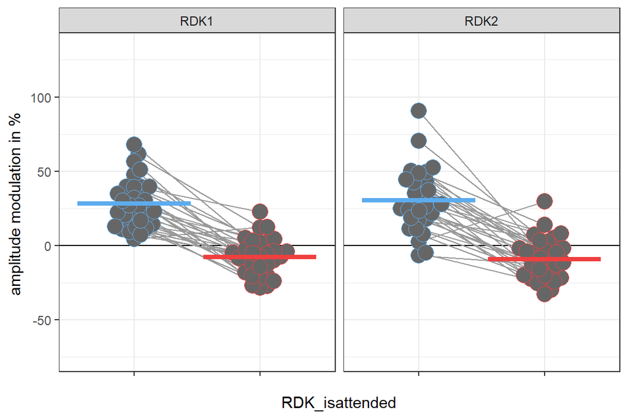

```r
# set limits
yax_limits <- c( min(dat2plot$modulation_evoked), max(dat2plot$modulation_evoked))
yax_limits <- round(yax_limits + c(-1, 1)*diff(yax_limits)*0.1)
yax_limits <- yax_limits + c(-1, 1)*diff(yax_limits)*0.2


theme_set(theme_bw())
ggplot(dat2plot, aes(x = RDK_isattended, y = modulation_evoked, fill = RDK_isattended)) +
  geom_hline(yintercept=0, show.legend = FALSE) +
  geom_line(aes(group = interaction(subjects,time)),colour = "grey60",alpha = 1,size =0.5) +
  geom_beeswarm(aes(color = RDK_isattended, x = RDK_isattended,
                    group = RDK_isattended), cex=3, size = 5,alpha=1,fill="grey40",shape=21)+
  # geom_point(aes(color = RDK_isattended, x = interaction(time,RDK_isattended),
  #                   group = RDK_isattended), size = 4,alpha=0.4)+
  stat_summary(fun.y=mean, aes(ymin=..y.., ymax=..y.., color =RDK_isattended), geom='errorbar', width=0.9, size=1.5) +
  scale_x_discrete("RDK_isattended", breaks=waiver(), labels = rep(c(""),1,2)) +
  # theme(legend.position="bottom") +
  facet_grid(.~RDK_id)+
  ylab(expression(paste("amplitude modulation in %")))+
  scale_fill_manual(values=c("steelblue2", "#F03F3F"))+
  scale_color_manual(values=c("steelblue2", "#F03F3F"))+
  #  scale_fill_manual(values=c("#193A3D", "#F03F3F"))+
  # scale_color_manual(values=c("#193A3D", "#F03F3F"))+
  # scale_fill_manual(values=c(rgb2hex(0.0, 153.0, 204.0),rgb2hex(0.0, 77, 102.0)))+
  # scale_color_manual(values=c(rgb2hex(0.0, 153.0, 204.0),rgb2hex(0.0, 77, 102.0)))+
  theme(legend.position="none")+
  # scale_y_continuous(limits=c(-60, 140))
  scale_y_continuous(limits=yax_limits)
```

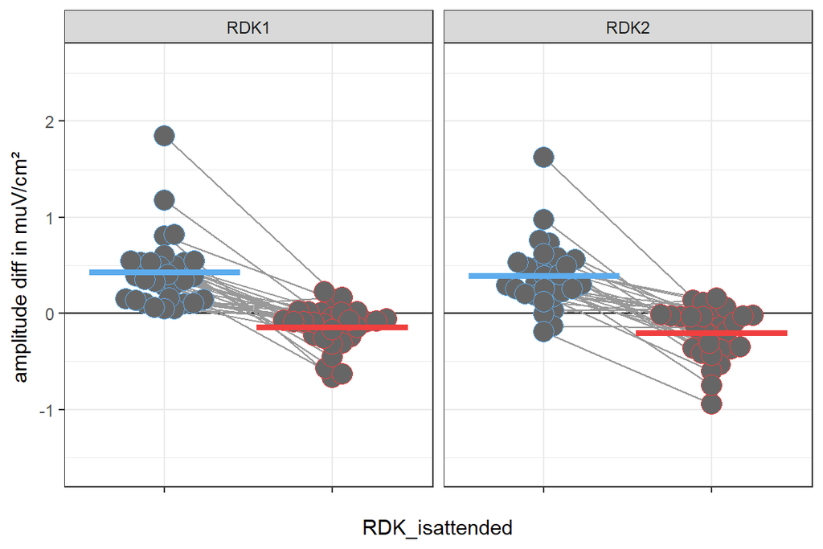

```r
# set limits
yax_limits <- c( min(dat2plot$subtraction_evoked), max(dat2plot$subtraction_evoked))
yax_limits <- round(yax_limits + c(-1, 1)*diff(yax_limits)*0.1)
yax_limits <- yax_limits + c(-1, 1)*diff(yax_limits)*0.2


theme_set(theme_bw())
ggplot(dat2plot, aes(x = RDK_isattended, y = subtraction_evoked, fill = RDK_isattended)) +
  geom_hline(yintercept=0, show.legend = FALSE) +
  geom_line(aes(group = interaction(subjects,time)),colour = "grey60",alpha = 1,size =0.5) +
  geom_beeswarm(aes(color = RDK_isattended, x = RDK_isattended,
                    group = RDK_isattended), cex=3, size = 5,alpha=1,fill="grey40",shape=21)+
  # geom_point(aes(color = RDK_isattended, x = interaction(time,RDK_isattended),
  #                   group = RDK_isattended), size = 4,alpha=0.4)+
  stat_summary(fun.y=mean, aes(ymin=..y.., ymax=..y.., color =RDK_isattended), geom='errorbar', width=0.9, size=1.5) +
  scale_x_discrete("RDK_isattended", breaks=waiver(), labels = rep(c(""),1,2)) +
  # theme(legend.position="bottom") +
  facet_grid(.~RDK_id)+
  ylab(expression(paste("amplitude diff in muV/cm²")))+
  scale_fill_manual(values=c("steelblue2", "#F03F3F"))+
  scale_color_manual(values=c("steelblue2", "#F03F3F"))+
  #  scale_fill_manual(values=c("#193A3D", "#F03F3F"))+
  # scale_color_manual(values=c("#193A3D", "#F03F3F"))+
  # scale_fill_manual(values=c(rgb2hex(0.0, 153.0, 204.0),rgb2hex(0.0, 77, 102.0)))+
  # scale_color_manual(values=c(rgb2hex(0.0, 153.0, 204.0),rgb2hex(0.0, 77, 102.0)))+
  theme(legend.position="none")+
  # scale_y_continuous(limits=c(-60, 140))
  scale_y_continuous(limits=yax_limits)
```

```r
# set overall limits?

dat2plot <- DataIn %>%
  filter(RDK_position2=="center") %>%
  group_by(subjects, time, RDK_isattended, RDK_colorlum, RDK_id, condition)%>%
  summarise(amplitude_evoked=mean(amplitude_evoked), modulation_evoked=mean(modulation_evoked), subtraction_evoked = mean(subtraction_evoked))%>%
  filter(time=='[0.5 1.5] ', RDK_colorlum == 'isolum__to_bckgrd')
```

```
## 'RDK_colorlum', 'RDK_id'. You can override using the `.groups` argument.
```

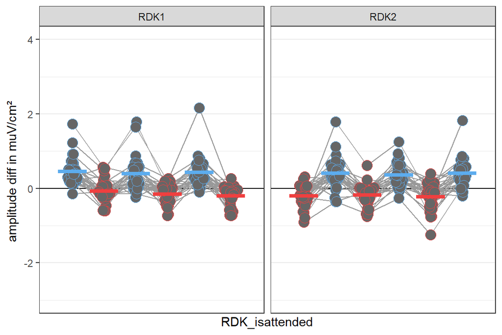

```r
yax_limits <- c( min(dat2plot$subtraction_evoked), max(dat2plot$subtraction_evoked))
yax_limits <- round(yax_limits + c(-1, 1)*diff(yax_limits)*0.1)
yax_limits <- yax_limits + c(-1, 1)*diff(yax_limits)*0.2


theme_set(theme_bw())
ggplot(dat2plot, aes(x = condition, y = subtraction_evoked, fill = RDK_isattended)) +
  geom_hline(yintercept=0, show.legend = FALSE) +
  geom_line(aes(group = interaction(subjects,time)),colour = "grey60",alpha = 1,size =0.5) +
  geom_beeswarm(aes(color = RDK_isattended, x = condition,
                    group = condition), cex=3, size = 4,alpha=1,fill="grey40",shape=21)+
  # geom_point(aes(color = RDK_isattended, x = interaction(time,RDK_isattended),
  #                   group = RDK_isattended), size = 4,alpha=0.4)+
  stat_summary(fun.y=mean, aes(ymin=..y.., ymax=..y.., color =RDK_isattended), geom='errorbar', width=0.9, size=1.5) +
  scale_x_discrete("RDK_isattended", breaks=waiver(), labels = rep(c(""),1,2)) +
  # theme(legend.position="bottom") +
  facet_grid(.~RDK_id)+
  ylab(expression(paste("amplitude diff in muV/cm²")))+
  scale_fill_manual(values=c("steelblue2", "#F03F3F"))+
  scale_color_manual(values=c("steelblue2", "#F03F3F"))+
  #  scale_fill_manual(values=c("#193A3D", "#F03F3F"))+
  # scale_color_manual(values=c("#193A3D", "#F03F3F"))+
  # scale_fill_manual(values=c(rgb2hex(0.0, 153.0, 204.0),rgb2hex(0.0, 77, 102.0)))+
  # scale_color_manual(values=c(rgb2hex(0.0, 153.0, 204.0),rgb2hex(0.0, 77, 102.0)))+
  theme(legend.position="none")+
  # scale_y_continuous(limits=c(-60, 140))
  scale_y_continuous(limits=yax_limits)
```

```r
dat2plot <- DataIn %>%
  filter(RDK_position2=="center") %>%
  group_by(subjects, time, RDK_isattended, RDK_colorlum, RDK_id, condition)%>%
  summarise(amplitude_evoked=mean(amplitude_evoked), modulation_evoked=mean(modulation_evoked), subtraction_evoked = mean(subtraction_evoked))%>%
  filter(time=='[0.5 1.5] ', RDK_colorlum == 'isolum__to_bckgrd')
```

```
## 'RDK_colorlum', 'RDK_id'. You can override using the `.groups` argument.
```

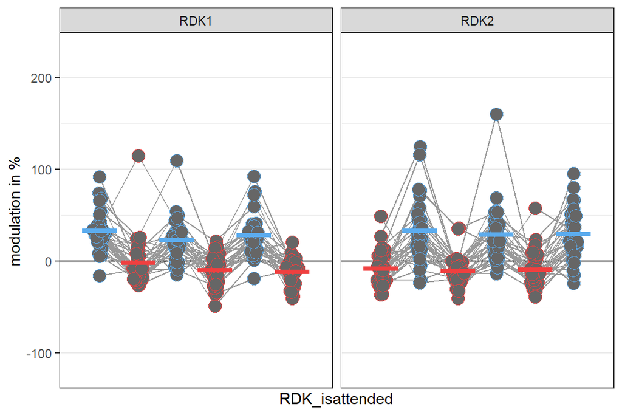

```r
yax_limits <- c( min(dat2plot$modulation_evoked), max(dat2plot$modulation_evoked))
yax_limits <- round(yax_limits + c(-1, 1)*diff(yax_limits)*0.1)
yax_limits <- yax_limits + c(-1, 1)*diff(yax_limits)*0.2


theme_set(theme_bw())
ggplot(dat2plot, aes(x = condition, y = modulation_evoked, fill = RDK_isattended)) +
  geom_hline(yintercept=0, show.legend = FALSE) +
  geom_line(aes(group = interaction(subjects,time)),colour = "grey60",alpha = 1,size =0.5) +
  geom_beeswarm(aes(color = RDK_isattended, x = condition,
                    group = condition), cex=3, size = 4,alpha=1,fill="grey40",shape=21)+
  # geom_point(aes(color = RDK_isattended, x = interaction(time,RDK_isattended),
  #                   group = RDK_isattended), size = 4,alpha=0.4)+
  stat_summary(fun.y=mean, aes(ymin=..y.., ymax=..y.., color =RDK_isattended), geom='errorbar', width=0.9, size=1.5) +
  scale_x_discrete("RDK_isattended", breaks=waiver(), labels = rep(c(""),1,2)) +
  # theme(legend.position="bottom") +
  facet_grid(.~RDK_id)+
  ylab(expression(paste("modulation in %")))+
  scale_fill_manual(values=c("steelblue2", "#F03F3F"))+
  scale_color_manual(values=c("steelblue2", "#F03F3F"))+
  #  scale_fill_manual(values=c("#193A3D", "#F03F3F"))+
  # scale_color_manual(values=c("#193A3D", "#F03F3F"))+
  # scale_fill_manual(values=c(rgb2hex(0.0, 153.0, 204.0),rgb2hex(0.0, 77, 102.0)))+
  # scale_color_manual(values=c(rgb2hex(0.0, 153.0, 204.0),rgb2hex(0.0, 77, 102.0)))+
  theme(legend.position="none")+
  # scale_y_continuous(limits=c(-60, 140))
  scale_y_continuous(limits=yax_limits)
```

```r
# corrdata <- DataIn %>%
#   mutate(sign_modulation = sign(modulation_evoked), sign_subtraction=sign(subtraction_evoked) )
#
# ggscatter(corrdat3,
#           x = "POS",
#           y = "POS_X_COL",
#           size = 2,
#           palette = "jco",
#           add = "reg.line",
#           conf.int = TRUE) +
#   # stat_cor(aes(color = con_RDK_col_attended), method = "spearman", label.y = 60) +
#   stat_cor( method = "spearman") +
#   # stat_cor(aes(color = con_RDK_col_attended), method = "pearson", label.y = 60) +
#   ggtitle("Spearman Rank Correlations | amplitude modulations separate for pos.")
```

### 2a Illustrate Data as is | peri RDKs

```r
#evoked raw#### for center
dat2plot <- DataIn %>%
  filter(RDK_position2=="peri") %>%
  filter(RDK_ispresented=="presented")%>%
  group_by(subjects, time, RDK_isattended, RDK_colorlum)%>%
  summarise(amplitude_evoked=mean(amplitude_evoked), modulation_evoked=mean(modulation_evoked))
```

```
## can override using the `.groups` argument.
```

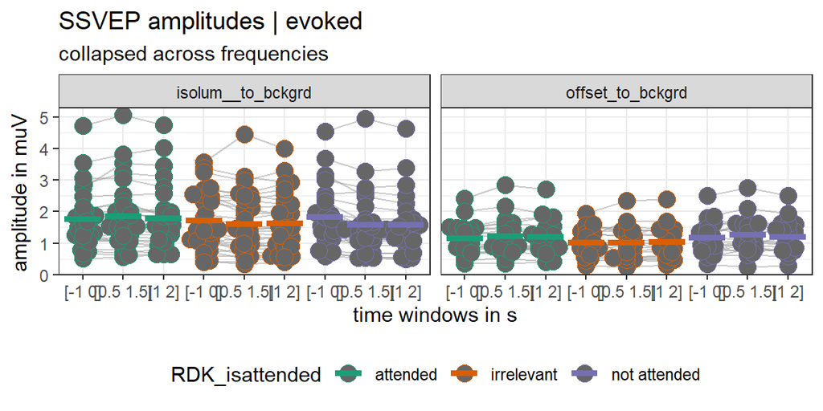

```r
theme_set(theme_bw())
ggplot(dat2plot, aes(x = interaction(time,RDK_isattended), y = amplitude_evoked, fill = RDK_isattended)) +
  # geom_hline(yintercept=0, show.legend = FALSE) +
  geom_line(aes(group = interaction(subjects,RDK_isattended)),colour = "grey60",alpha = 0.5,size =0.5) +
  geom_beeswarm(aes(color = RDK_isattended, x = interaction(time,RDK_isattended),
                    group = RDK_isattended), cex=2, size = 4,alpha=1,fill="grey40",shape=21)+
  # geom_point(aes(color = condition, x = interaction(time,condition),
  #                   group = condition), size = 4,alpha=0.4)+
  stat_summary(fun.y=mean, aes(ymin=..y.., ymax=..y.., color =RDK_isattended), geom='errorbar', width=0.9, size=1.5) +
  scale_x_discrete("time windows in s", breaks=waiver(), labels = rep(c("[-1 0]","[0.5 1.5]","[1 2]"),1,9)) +
  facet_grid(.~RDK_colorlum)+
  theme(legend.position="bottom") +
  ylab(expression(paste("amplitude in muV")))+
  labs(title=sprintf("SSVEP amplitudes | evoked"),
       subtitle="collapsed across frequencies")+
  scale_fill_brewer(palette = "Dark2")+
  scale_color_brewer(palette = "Dark2")
```

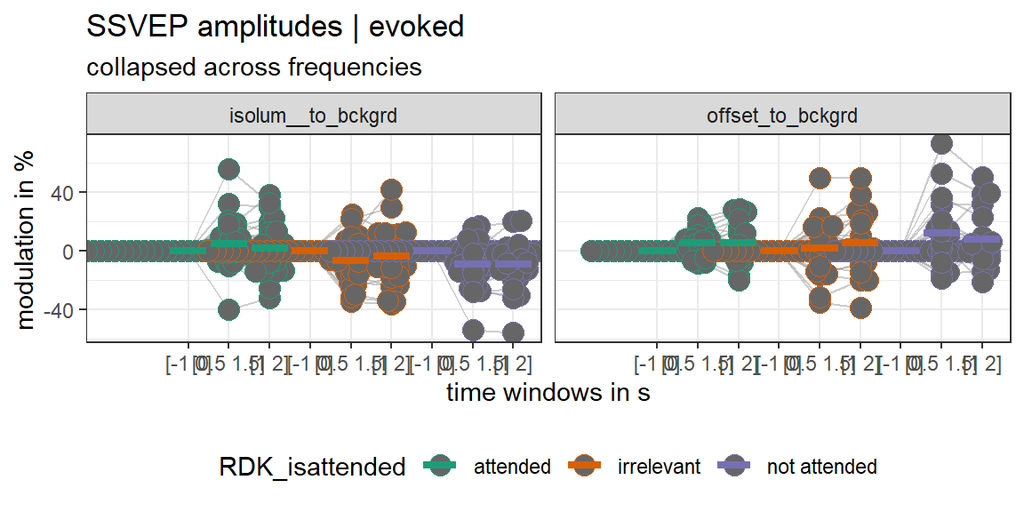

```r
theme_set(theme_bw())
ggplot(dat2plot, aes(x = interaction(time,RDK_isattended), y = modulation_evoked, fill = RDK_isattended)) +
  # geom_hline(yintercept=0, show.legend = FALSE) +
  geom_line(aes(group = interaction(subjects,RDK_isattended)),colour = "grey60",alpha = 0.5,size =0.5) +
  geom_beeswarm(aes(color = RDK_isattended, x = interaction(time,RDK_isattended),
                    group = RDK_isattended), cex=2, size = 4,alpha=1,fill="grey40",shape=21)+
  # geom_point(aes(color = condition, x = interaction(time,condition),
  #                   group = condition), size = 4,alpha=0.4)+
  stat_summary(fun.y=mean, aes(ymin=..y.., ymax=..y.., color =RDK_isattended), geom='errorbar', width=0.9, size=1.5) +
  scale_x_discrete("time windows in s", breaks=waiver(), labels = rep(c("[-1 0]","[0.5 1.5]","[1 2]"),1,9)) +
  facet_grid(.~RDK_colorlum)+
  theme(legend.position="bottom") +
  ylab(expression(paste("modulation in %")))+
  labs(title=sprintf("SSVEP amplitudes | evoked"),
       subtitle="collapsed across frequencies")+
  scale_fill_brewer(palette = "Dark2")+
  scale_color_brewer(palette = "Dark2")
```

### 2b Illustrate Data as is | peri RDKs

plot differently

```r
#evoked raw#### for periphery
# general ylims
dat2plot <- DataIn %>%
  filter(RDK_position2=="peri") %>%
  filter(RDK_ispresented=="presented")%>%
  group_by(subjects, time, RDK_isattended, RDK_colorlum)%>%
  summarise(amplitude_evoked=mean(amplitude_evoked), modulation_evoked=mean(modulation_evoked))%>%
  filter(time=='[0.5 1.5] ', RDK_colorlum == 'isolum__to_bckgrd')
```

```
## can override using the `.groups` argument.
```

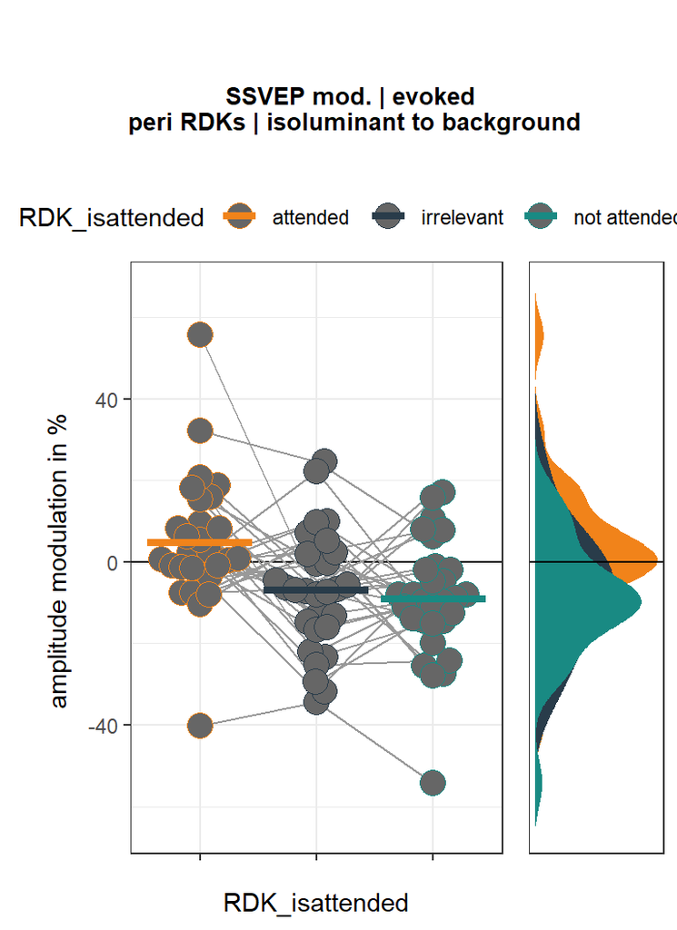

```r
# set limits
yax_limits <- c( min(dat2plot$modulation_evoked), max(dat2plot$modulation_evoked))
yax_limits <- round(yax_limits + c(-1, 1)*diff(yax_limits)*0.1)
# yax_limits <- yax_limits + c(-1, 1)*diff(yax_limits)*0.2
# yax_limits <- c(-27, 15)


theme_set(theme_bw())
plot1 <- ggplot(dat2plot, aes(x = RDK_isattended, y = modulation_evoked, fill = RDK_isattended)) +
  geom_hline(yintercept=0, show.legend = FALSE) +
  geom_line(aes(group = interaction(subjects,time)),colour = "grey60",alpha = 1,size =0.5) +
  geom_beeswarm(aes(color = RDK_isattended, x = RDK_isattended,
                    group = RDK_isattended), cex=3, size = 5,alpha=1,fill="grey40",shape=21)+
  # geom_point(aes(color = RDK_isattended, x = interaction(time,RDK_isattended),
  #                   group = RDK_isattended), size = 4,alpha=0.4)+
  stat_summary(fun.y=mean, aes(ymin=..y.., ymax=..y.., color =RDK_isattended), geom='errorbar', width=0.9, size=1.5) +
  scale_x_discrete("RDK_isattended", breaks=waiver(), labels = rep(c(""),1,3)) +
  # theme(legend.position="bottom") +
  ylab(expression(paste("amplitude modulation in %")))+
  scale_fill_manual(values=c("#F1831A", "#293C4A", "#198A83"))+
  scale_color_manual(values=c("#F1831A", "#293C4A", "#198A83"))+
  theme(legend.position="none")+
  # scale_y_continuous(limits=c(-60, 140))
  scale_y_continuous(limits=yax_limits)


plot2 <- ggplot(dat2plot, aes(y = modulation_evoked, fill = RDK_isattended, x = 1)) +
  geom_flat_violin(aes(fill = RDK_isattended),position = position_nudge(x = .1, y = 0),
                   adjust = 1.3, trim = FALSE, alpha = 1, colour = NA)+
  geom_hline(yintercept=0, show.legend = FALSE) +
  scale_fill_manual(values=c("#F1831A", "#293C4A", "#198A83"))+
  scale_color_manual(values=c("#F1831A", "#293C4A", "#198A83"))+
  theme(axis.title.y=element_blank(),
        axis.text.y=element_blank(),
        axis.ticks.y=element_blank())+
  theme(axis.title.x=element_blank(),
        axis.text.x=element_blank(),
        axis.ticks.x=element_blank())+
  theme(panel.grid.major = element_blank(), panel.grid.minor = element_blank())+
  # scale_y_continuous(limits=c(-60, 140))
  scale_y_continuous(limits=yax_limits)



# cowplot::plot_grid(plot1, plot2, plot3, ncol = 3,labels = "AUTO")
plotttitle <- ggdraw() +
  draw_label("SSVEP mod. | evoked \nperi RDKs | isoluminant to background", fontface='bold', size = 10)
plotplots <- ggarrange(plot1, plot2,ncol = 2,common.legend = TRUE,align = "h", widths=c(3,1))

savefig <- multi_panel_figure(columns = 1, rows = 1, panel_label_type = "none", width = 4, height = 5.5, unit = "in")
saveplot <- ggarrange(plotttitle, plotplots, nrow = 2, heights=c(0.2, 1))

savefig %<>%
  fill_panel(saveplot, column = 1, row = 1)
savefig
```

```r
# save_multi_panel_figure(savefig, "figures/FFT_BeeSwarm_Mod_ALPHA_COL_34subs.eps")



dat2plot <- DataIn %>%
  filter(RDK_position2=="peri") %>%
  filter(RDK_ispresented=="presented")%>%
  group_by(subjects, time, RDK_isattended, RDK_colorlum)%>%
  summarise(subtraction_evoked=mean(subtraction_evoked), modulation_evoked=mean(modulation_evoked))%>%
  filter(time=='[0.5 1.5] ', RDK_colorlum == 'isolum__to_bckgrd')
```

```
## can override using the `.groups` argument.
```

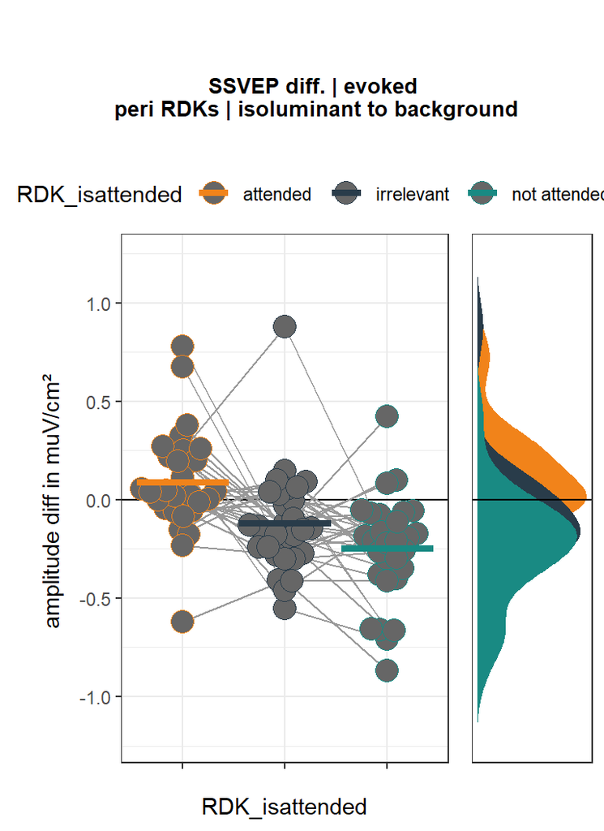

```r
# set limits
yax_limits <- c( min(dat2plot$subtraction_evoked), max(dat2plot$subtraction_evoked))
# yax_limits <- round(yax_limits + c(-1, 1)*diff(yax_limits)*0.1)
yax_limits <- yax_limits + c(-1, 1)*diff(yax_limits)*0.2
# yax_limits <- c(-27, 15)


theme_set(theme_bw())
plot1 <- ggplot(dat2plot, aes(x = RDK_isattended, y = subtraction_evoked, fill = RDK_isattended)) +
  geom_hline(yintercept=0, show.legend = FALSE) +
  geom_line(aes(group = interaction(subjects,time)),colour = "grey60",alpha = 1,size =0.5) +
  geom_beeswarm(aes(color = RDK_isattended, x = RDK_isattended,
                    group = RDK_isattended), cex=3, size = 5,alpha=1,fill="grey40",shape=21)+
  # geom_point(aes(color = RDK_isattended, x = interaction(time,RDK_isattended),
  #                   group = RDK_isattended), size = 4,alpha=0.4)+
  stat_summary(fun.y=mean, aes(ymin=..y.., ymax=..y.., color =RDK_isattended), geom='errorbar', width=0.9, size=1.5) +
  scale_x_discrete("RDK_isattended", breaks=waiver(), labels = rep(c(""),1,3)) +
  # theme(legend.position="bottom") +
  ylab(expression(paste("amplitude diff in muV/cm²")))+
  scale_fill_manual(values=c("#F1831A", "#293C4A", "#198A83"))+
  scale_color_manual(values=c("#F1831A", "#293C4A", "#198A83"))+
  theme(legend.position="none")+
  # scale_y_continuous(limits=c(-60, 140))
  scale_y_continuous(limits=yax_limits)


plot2 <- ggplot(dat2plot, aes(y = subtraction_evoked, fill = RDK_isattended, x = 1)) +
  geom_flat_violin(aes(fill = RDK_isattended),position = position_nudge(x = .1, y = 0),
                   adjust = 1.3, trim = FALSE, alpha = 1, colour = NA)+
  geom_hline(yintercept=0, show.legend = FALSE) +
  scale_fill_manual(values=c("#F1831A", "#293C4A", "#198A83"))+
  scale_color_manual(values=c("#F1831A", "#293C4A", "#198A83"))+
  theme(axis.title.y=element_blank(),
        axis.text.y=element_blank(),
        axis.ticks.y=element_blank())+
  theme(axis.title.x=element_blank(),
        axis.text.x=element_blank(),
        axis.ticks.x=element_blank())+
  theme(panel.grid.major = element_blank(), panel.grid.minor = element_blank())+
  # scale_y_continuous(limits=c(-60, 140))
  scale_y_continuous(limits=yax_limits)



# cowplot::plot_grid(plot1, plot2, plot3, ncol = 3,labels = "AUTO")
plotttitle <- ggdraw() +
  draw_label("SSVEP diff. | evoked \nperi RDKs | isoluminant to background", fontface='bold', size = 10)
plotplots <- ggarrange(plot1, plot2,ncol = 2,common.legend = TRUE,align = "h", widths=c(3,1))

savefig <- multi_panel_figure(columns = 1, rows = 1, panel_label_type = "none", width = 4, height = 5.5, unit = "in")
saveplot <- ggarrange(plotttitle, plotplots, nrow = 2, heights=c(0.2, 1))

savefig %<>%
  fill_panel(saveplot, column = 1, row = 1)
savefig
```

```r
# save_multi_panel_figure(savefig, "figures/FFT_BeeSwarm_Mod_ALPHA_COL_34subs.eps")
```

### 2c Illustrate Data as is | peri RDKs

plot all conditions

```r
#evoked raw#### for periphery
dat2plot <- DataIn %>%
  filter(RDK_position2=="peri") %>%
  filter(RDK_ispresented=="presented")%>%
  group_by(subjects, time, RDK_isattended2, RDK_colorlum)%>%
  summarise(amplitude_evoked=mean(amplitude_evoked), modulation_evoked=mean(modulation_evoked))%>%
  filter(time=='[0.5 1.5] ', RDK_colorlum == 'isolum__to_bckgrd')
```

```
## can override using the `.groups` argument.
```

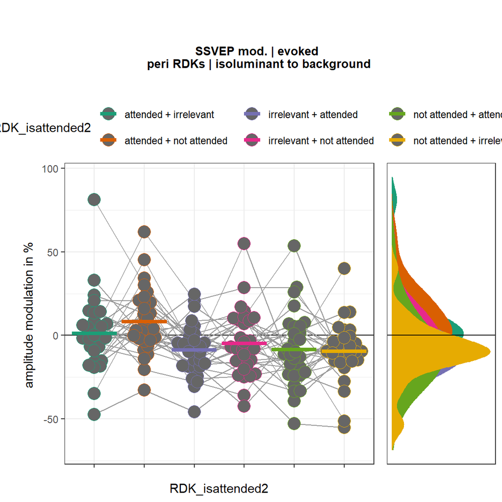

```r
# set general limits
yax_limits <- c( min(dat2plot$modulation_evoked), max(dat2plot$modulation_evoked))
yax_limits <- round(yax_limits + c(-1, 1)*diff(yax_limits)*0.1)
# yax_limits <- yax_limits + c(-1, 1)*diff(yax_limits)*0.2
# yax_limits <- c(-27, 15)

theme_set(theme_bw())
plot1 <- ggplot(dat2plot, aes(x = RDK_isattended2, y = modulation_evoked, fill = RDK_isattended2)) +
  geom_hline(yintercept=0, show.legend = FALSE) +
  geom_line(aes(group = interaction(subjects,time)),colour = "grey60",alpha = 1,size =0.5) +
  geom_beeswarm(aes(color = RDK_isattended2, x = RDK_isattended2,
                    group = RDK_isattended2), cex=2, size = 5,alpha=1,fill="grey40",shape=21)+
  # geom_point(aes(color = RDK_isattended2, x = interaction(time,RDK_isattended),
  #                   group = RDK_isattended2), size = 4,alpha=0.4)+
  stat_summary(fun.y=mean, aes(ymin=..y.., ymax=..y.., color =RDK_isattended2), geom='errorbar', width=0.9, size=1.5) +
  scale_x_discrete("RDK_isattended2", breaks=waiver(), labels = rep(c(""),1,6)) +
  # theme(legend.position="bottom") +
  ylab(expression(paste("amplitude modulation in %")))+
  scale_fill_brewer(palette = "Dark2")+
  scale_color_brewer(palette = "Dark2")+
  theme(legend.position="none")+
  # scale_y_continuous(limits=c(-60, 140))
  scale_y_continuous(limits=yax_limits)

plot2 <- ggplot(dat2plot, aes(y = modulation_evoked, fill = RDK_isattended2, x = 1)) +
  geom_flat_violin(aes(fill = RDK_isattended2),position = position_nudge(x = .1, y = 0),
                   adjust = 1.3, trim = FALSE, alpha = 1, colour = NA)+
  geom_hline(yintercept=0, show.legend = FALSE) +
  scale_fill_brewer(palette = "Dark2")+
  scale_color_brewer(palette = "Dark2")+
  theme(axis.title.y=element_blank(),
        axis.text.y=element_blank(),
        axis.ticks.y=element_blank())+
  theme(axis.title.x=element_blank(),
        axis.text.x=element_blank(),
        axis.ticks.x=element_blank())+
  theme(panel.grid.major = element_blank(), panel.grid.minor = element_blank())+
  # scale_y_continuous(limits=c(-60, 140))
  scale_y_continuous(limits=yax_limits)



# cowplot::plot_grid(plot1, plot2, plot3, ncol = 3,labels = "AUTO")
plotttitle <- ggdraw() +
  draw_label("SSVEP mod. | evoked \nperi RDKs | isoluminant to background", fontface='bold', size = 10)
plotplots <- ggarrange(plot1, plot2,ncol = 2,common.legend = TRUE,align = "h", widths=c(3,1))

savefig <- multi_panel_figure(columns = 1, rows = 1, panel_label_type = "none", width = 6, height = 6, unit = "in")
saveplot <- ggarrange(plotttitle, plotplots, nrow = 2, heights=c(0.2, 1))

savefig %<>%
  fill_panel(saveplot, column = 1, row = 1)
savefig
```

```r
# save_multi_panel_figure(savefig, "figures/FFT_BeeSwarm_Mod_ALPHA_COL_34subs.eps")


###
# plot difference
####
dat2plot <- DataIn %>%
  filter(RDK_position2=="peri") %>%
  filter(RDK_ispresented=="presented")%>%
  group_by(subjects, time, RDK_isattended2, RDK_colorlum)%>%
  summarise(subtraction_evoked=mean(subtraction_evoked), modulation_evoked=mean(modulation_evoked))%>%
  filter(time=='[0.5 1.5] ', RDK_colorlum == 'isolum__to_bckgrd')
```

```
## can override using the `.groups` argument.
```

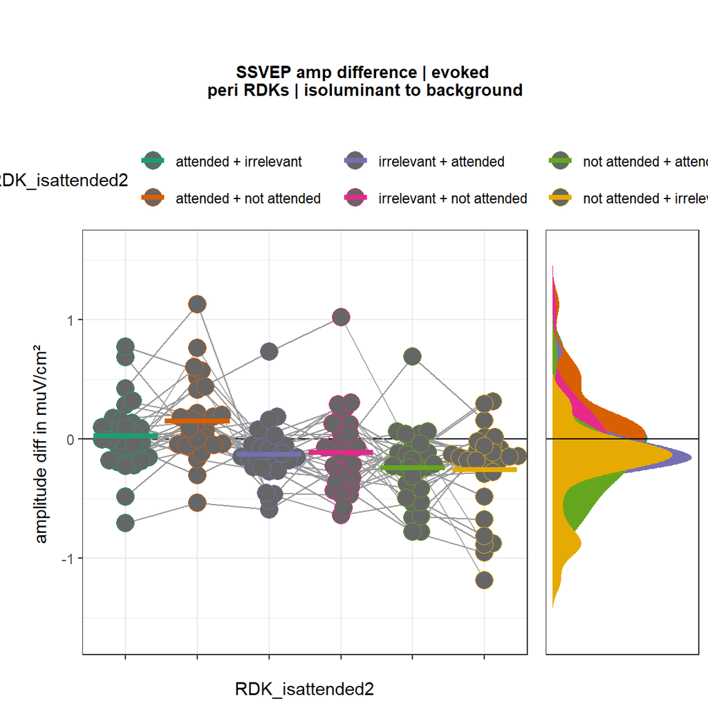

```r
# set general limits
yax_limits <- c( min(dat2plot$subtraction_evoked), max(dat2plot$subtraction_evoked))
# yax_limits <- round(yax_limits + c(-1, 1)*diff(yax_limits)*0.1)
yax_limits <- yax_limits + c(-1, 1)*diff(yax_limits)*0.2
# yax_limits <- c(-27, 15)

theme_set(theme_bw())
plot1 <- ggplot(dat2plot, aes(x = RDK_isattended2, y = subtraction_evoked, fill = RDK_isattended2)) +
  geom_hline(yintercept=0, show.legend = FALSE) +
  geom_line(aes(group = interaction(subjects,time)),colour = "grey60",alpha = 1,size =0.5) +
  geom_beeswarm(aes(color = RDK_isattended2, x = RDK_isattended2,
                    group = RDK_isattended2), cex=2, size = 5,alpha=1,fill="grey40",shape=21)+
  # geom_point(aes(color = RDK_isattended2, x = interaction(time,RDK_isattended),
  #                   group = RDK_isattended2), size = 4,alpha=0.4)+
  stat_summary(fun.y=mean, aes(ymin=..y.., ymax=..y.., color =RDK_isattended2), geom='errorbar', width=0.9, size=1.5) +
  scale_x_discrete("RDK_isattended2", breaks=waiver(), labels = rep(c(""),1,6)) +
  # theme(legend.position="bottom") +
  ylab(expression(paste("amplitude diff in muV/cm²")))+
  scale_fill_brewer(palette = "Dark2")+
  scale_color_brewer(palette = "Dark2")+
  theme(legend.position="none")+
  # scale_y_continuous(limits=c(-60, 140))
  scale_y_continuous(limits=yax_limits)

plot2 <- ggplot(dat2plot, aes(y = subtraction_evoked, fill = RDK_isattended2, x = 1)) +
  geom_flat_violin(aes(fill = RDK_isattended2),position = position_nudge(x = .1, y = 0),
                   adjust = 1.3, trim = FALSE, alpha = 1, colour = NA)+
  geom_hline(yintercept=0, show.legend = FALSE) +
  scale_fill_brewer(palette = "Dark2")+
  scale_color_brewer(palette = "Dark2")+
  theme(axis.title.y=element_blank(),
        axis.text.y=element_blank(),
        axis.ticks.y=element_blank())+
  theme(axis.title.x=element_blank(),
        axis.text.x=element_blank(),
        axis.ticks.x=element_blank())+
  theme(panel.grid.major = element_blank(), panel.grid.minor = element_blank())+
  # scale_y_continuous(limits=c(-60, 140))
  scale_y_continuous(limits=yax_limits)



# cowplot::plot_grid(plot1, plot2, plot3, ncol = 3,labels = "AUTO")
plotttitle <- ggdraw() +
  draw_label("SSVEP amp difference | evoked \nperi RDKs | isoluminant to background", fontface='bold', size = 10)
plotplots <- ggarrange(plot1, plot2,ncol = 2,common.legend = TRUE,align = "h", widths=c(3,1))

savefig <- multi_panel_figure(columns = 1, rows = 1, panel_label_type = "none", width = 6, height = 6, unit = "in")
saveplot <- ggarrange(plotttitle, plotplots, nrow = 2, heights=c(0.2, 1))

savefig %<>%
  fill_panel(saveplot, column = 1, row = 1)
savefig
```

```r
# save_multi_panel_figure(savefig, "figures/FFT_BeeSwarm_Mod_ALPHA_COL_34subs.eps")
```

### 2d Illustrate Data as is | peri RDKs

plot all conditions in combination they were actually presented

```r
#evoked raw#### for periphery
dat2plot <- DataIn %>%
  mutate(condition2 = case_when(
    (condition == 1 | condition == 2) ~ "peri_att_unatt",
    (condition == 3 | condition == 4) ~ "peri_att_irrel",
    (condition == 5 | condition == 6) ~ "peri_unatt_irrel",
  )) %>%
  filter(RDK_position2=="peri") %>%
  filter(RDK_ispresented=="presented")%>%
  group_by(subjects, time, RDK_isattended, RDK_colorlum, condition2)%>%
  summarise(amplitude_evoked=mean(amplitude_evoked), modulation_evoked=mean(modulation_evoked))%>%
  filter(time=='[0.5 1.5] ')
```

```
## 'RDK_colorlum'. You can override using the `.groups` argument.
```

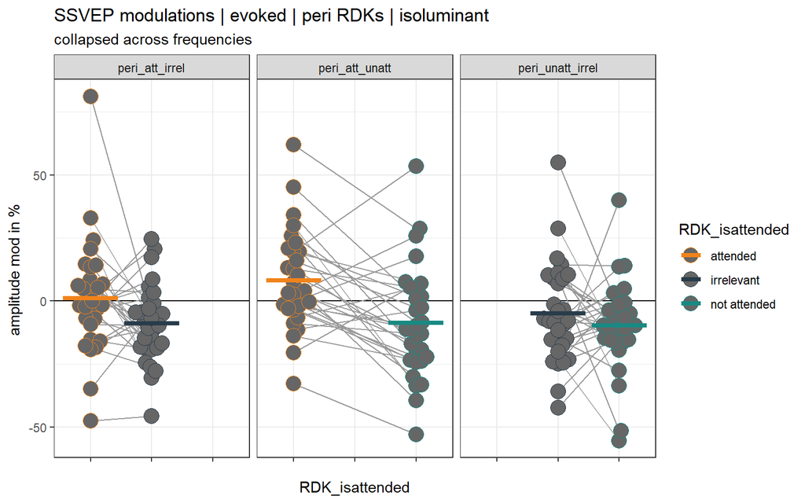

```r
dat2plot2 <- dat2plot %>%
  filter(RDK_colorlum == 'isolum__to_bckgrd')


theme_set(theme_bw())
ggplot(dat2plot2, aes(x = RDK_isattended, y = modulation_evoked, fill = RDK_isattended)) +
  geom_hline(yintercept=0, show.legend = FALSE) +
  geom_line(aes(group = interaction(subjects,time)),colour = "grey60",alpha = 1,size =0.5) +
  geom_beeswarm(aes(color = RDK_isattended, x = RDK_isattended,
                    group = RDK_isattended), cex=3, size = 5,alpha=1,fill="grey40",shape=21)+
  # geom_point(aes(color = RDK_isattended, x = interaction(time,RDK_isattended),
  #                   group = RDK_isattended), size = 4,alpha=0.4)+
  stat_summary(fun.y=mean, aes(ymin=..y.., ymax=..y.., color =RDK_isattended), geom='errorbar', width=0.9, size=1.5) +
  scale_x_discrete("RDK_isattended", breaks=waiver(), labels = rep(c(""),1,3)) +
  # theme(legend.position="bottom") +
  facet_grid(.~condition2)+
  ylab(expression(paste("amplitude mod in %")))+
  scale_fill_manual(values=c("#F1831A", "#293C4A", "#198A83"))+
  scale_color_manual(values=c("#F1831A", "#293C4A", "#198A83"))+
  labs(title=sprintf("SSVEP modulations | evoked | peri RDKs | isoluminant"),
       subtitle="collapsed across frequencies")
```

```r
  # scale_y_continuous(limits=c(-60, 140))
```

### 3a Illustrate Data as is | peri and center | general modulation

plot differently

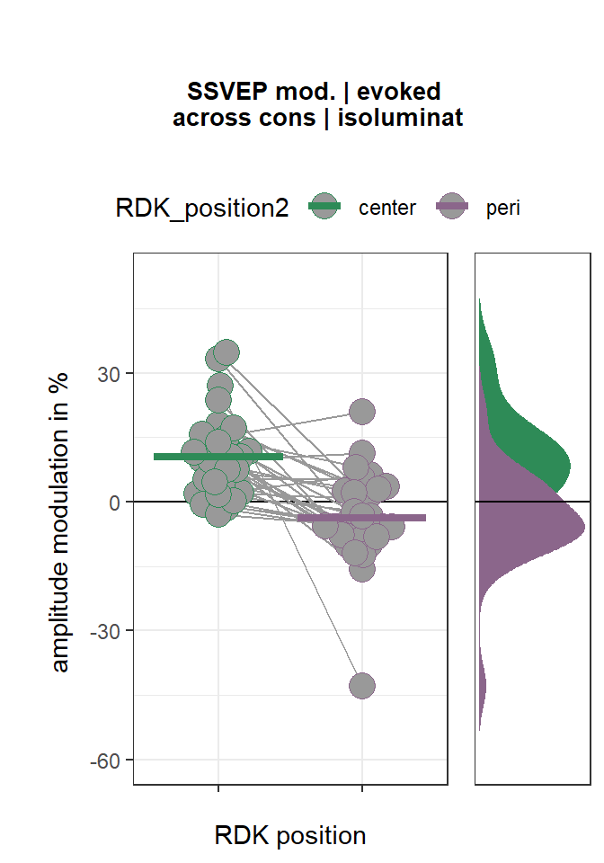

```r
#evoked raw#### for center

# set overall limits?
dat2plot <- DataIn %>%
  filter(RDK_ispresented=="presented", RDK_colorlum=="isolum__to_bckgrd")%>%
  group_by(subjects, time, RDK_position2)%>%
  summarise(amplitude_evoked=mean(amplitude_evoked), modulation_evoked=mean(modulation_evoked))%>%
  filter(time == '[0.5 1.5] ')
# set limits
yax_limits <- c( min(dat2plot$modulation_evoked), max(dat2plot$modulation_evoked))
yax_limits <- round(yax_limits + c(-1, 1)*diff(yax_limits)*0.1)
yax_limits <- yax_limits + c(-1, 1)*diff(yax_limits)*0.1


theme_set(theme_bw())
plot1 <- ggplot(dat2plot, aes(x = RDK_position2, y = modulation_evoked, fill = RDK_position2)) +
  geom_hline(yintercept=0, show.legend = FALSE) +
  geom_line(aes(group = interaction(subjects,time)),colour = "grey60",alpha = 1,size =0.5) +
  geom_beeswarm(aes(color = RDK_position2, x = RDK_position2,
                    group = RDK_position2), cex=3, size = 5,alpha=1,fill="grey60",shape=21)+
  # geom_point(aes(color = RDK_isattended, x = interaction(time,RDK_isattended),
  #                   group = RDK_isattended), size = 4,alpha=0.4)+
  stat_summary(fun.y=mean, aes(ymin=..y.., ymax=..y.., color =RDK_position2), geom='errorbar', width=0.9, size=1.5) +
  scale_x_discrete("RDK position", breaks=waiver(), labels = rep(c(""),1,2)) +
  # theme(legend.position="bottom") +
  ylab(expression(paste("amplitude modulation in %")))+
  scale_fill_manual(values=c("seagreen", "plum4"))+
  scale_color_manual(values=c("seagreen", "plum4"))+
  #  scale_fill_manual(values=c("#193A3D", "#F03F3F"))+
  # scale_color_manual(values=c("#193A3D", "#F03F3F"))+
  # scale_fill_manual(values=c(rgb2hex(0.0, 153.0, 204.0),rgb2hex(0.0, 77, 102.0)))+
  # scale_color_manual(values=c(rgb2hex(0.0, 153.0, 204.0),rgb2hex(0.0, 77, 102.0)))+
  theme(legend.position="none")+
  # scale_y_continuous(limits=c(-60, 140))
  scale_y_continuous(limits=yax_limits)


plot2 <- ggplot(dat2plot, aes(y = modulation_evoked, fill = RDK_position2, x = 1)) +
  geom_flat_violin(aes(fill = RDK_position2),position = position_nudge(x = .1, y = 0),
                   adjust = 1.3, trim = FALSE, alpha = 1, colour = NA)+
  geom_hline(yintercept=0, show.legend = FALSE) +
  # scale_fill_manual(values=c("#193A3D", "#F03F3F"))+
  # scale_color_manual(values=c("#193A3D", "#F03F3F"))+
  scale_fill_manual(values=c("seagreen", "plum4"))+
  scale_color_manual(values=c("seagreen", "plum4"))+
  # scale_fill_manual(values=c(rgb2hex(0.0, 153.0, 204.0),rgb2hex(0.0, 77, 102.0)))+
  # scale_color_manual(values=c(rgb2hex(0.0, 153.0, 204.0),rgb2hex(0.0, 77, 102.0)))+
  theme(axis.title.y=element_blank(),
        axis.text.y=element_blank(),
        axis.ticks.y=element_blank())+
  theme(axis.title.x=element_blank(),
        axis.text.x=element_blank(),
        axis.ticks.x=element_blank())+
  theme(panel.grid.major = element_blank(), panel.grid.minor = element_blank())+
  # scale_y_continuous(limits=c(-60, 140))
  scale_y_continuous(limits=yax_limits)



# cowplot::plot_grid(plot1, plot2, plot3, ncol = 3,labels = "AUTO")
plotttitle <- ggdraw() +
  draw_label("SSVEP mod. | evoked \nacross cons | isoluminat", fontface='bold', size = 10)
plotplots <- ggarrange(plot1, plot2,ncol = 2,common.legend = TRUE,align = "h", widths=c(3,1))

savefig <- multi_panel_figure(columns = 1, rows = 1, panel_label_type = "none", width = 3.5, height = 5, unit = "in")
saveplot <- ggarrange(plotttitle, plotplots, nrow = 2, heights=c(0.2, 1))

savefig %<>%
  fill_panel(saveplot, column = 1, row = 1)
savefig
```

```r
# save_multi_panel_figure(savefig, "figures/FFT_BeeSwarm_Mod_ALPHA_COL_34subs.eps")
```

## Statistical analysis

### Central Stimuli

#### analysis I

**modulation** ~ **COLOR ATTENTION**

- t-test post-cue modulation against zero for attended and unattended color
- t-test difference of post-cue modulation for attended vs unattended color

```r
dat2plot <- DataIn %>%
  filter(RDK_position2=="center") %>%
  group_by(subjects, time, RDK_isattended, RDK_colorlum)%>%
  summarise(amplitude_evoked=mean(amplitude_evoked), modulation_evoked=mean(modulation_evoked))%>%
  filter(time == '[0.5 1.5] ', RDK_colorlum == 'isolum__to_bckgrd')


dat2plot %>%
  group_by(RDK_isattended, RDK_colorlum)%>%
  nest()%>%
  mutate(stats = map(data, ~broom::tidy(
    t.test(modulation_evoked ~ 1, data = .)
  ))) %>%
  mutate(
    t_test_bf = map(data, ~{extractBF(ttestBF(x = .$modulation_evoked, data = .,iterations=num.iter,rscale = sqrt(2)/2))})
  )%>%
  mutate(meanval = map(data, ~ mean(.x$modulation_evoked))) %>%
  mutate(std = map(data, ~ sd(.x$modulation_evoked))) %>%
  dplyr::select(-data) %>%
  unnest(cols = c(stats, t_test_bf, meanval, std))%>%
  mutate(BF10 = bf, BF01 = 1/bf)%>%
  dplyr::select(RDK_colorlum, RDK_isattended, meanval, std,  statistic, parameter, p.value, BF10, BF01)%>%
  mutate(p.value = p.adjust(p.value, method="holm")) %>% # none, holm
  # mutate(p.value = p.adjust(p.value, method="none")) %>% # none, holm
  ungroup()%>%
  mutate(CohensD = `statistic`/sqrt(parameter +1))%>%
  mutate(
    p.value = cell_spec(ifelse(round(p.value,4)<.001,"< .001",round(p.value,4)),
                        color = ifelse(is.nan(p.value),"blue", ifelse(p.value < .05, "green", "red")),
                        bold = ifelse(is.nan(p.value),F, ifelse(p.value < .05, T,F)),
                        align = "center")
  ) %>%
  kbl(escape = F, digits = c(3,3,3,3,3,3,3,3,3),
        caption = c("central SSVEP | modulation | t-tests for modulation agains zero | Holm-corrected")) %>%
  kable_styling("striped", full_width = T, bootstrap_options = c("striped", "hover", "condensed", "responsive",font_size = 8))
```

central SSVEP | modulation | t-tests for modulation agains zero | Holm-corrected

| RDK_colorlum | RDK_isattended | meanval | std | statistic | parameter | p.value | BF10 | BF01 | CohensD |
| --- | --- | --- | --- | --- | --- | --- | --- | --- | --- |
| isolum__to_bckgrd | attended | 29.424 | 15.247 | 10.57 | 29 | < .001 | 496550591.438 | 0.000 | 1.930 |
| isolum__to_bckgrd | not attended | -8.373 | 11.186 | -4.10 | 29 | < .001 | 95.229 | 0.011 | -0.749 |

```r
dat2plot %>%
  dplyr::select(-amplitude_evoked)%>%
  pivot_wider(names_from = "RDK_isattended", values_from = "modulation_evoked")%>%
  mutate(attendedMINUSunattended = `attended` -`not attended`)%>%
  group_by(time, RDK_colorlum)%>%
  nest()%>%
  mutate(stats = map(data, ~broom::tidy(
    t.test(attendedMINUSunattended ~ 1, data = .)
  ))) %>%
  mutate(
    t_test_bf = map(data, ~{extractBF(ttestBF(x = .$attendedMINUSunattended, data = .,iterations=num.iter,rscale = sqrt(2)/2))})
  )%>%
  mutate(meanval = map(data, ~ mean(.x$attendedMINUSunattended))) %>%
  mutate(std = map(data, ~ sd(.x$attendedMINUSunattended))) %>%
  ungroup()%>%
  dplyr::select(-data, -time) %>%
  unnest(cols = c(stats, t_test_bf, meanval, std))%>%
  mutate(BF10 = bf, BF01 = 1/bf)%>%
  dplyr::select(RDK_colorlum, meanval, std,  statistic, parameter, p.value, BF10, BF01)%>%
  # mutate(p.value = p.adjust(p.value, method="holm")) %>% # none, holm
  # mutate(p.value = p.adjust(p.value, method="none")) %>% # none, holm
  ungroup()%>%
  mutate(CohensD = `statistic`/sqrt(parameter +1))%>%
  mutate(
    p.value = cell_spec(ifelse(round(p.value,4)<.001,"< .001",round(p.value,4)),
                        color = ifelse(is.nan(p.value),"blue", ifelse(p.value < .05, "green", "red")),
                        bold = ifelse(is.nan(p.value),F, ifelse(p.value < .05, T,F)),
                        align = "center")
  ) %>%
  kbl(escape = F, digits = c(3,3,3,3,3,3,3,3,3), caption = c("central SSVEP | modulation | attended - unattended ")) %>%
  kable_styling("striped", full_width = T, bootstrap_options = c("striped", "hover", "condensed", "responsive",font_size = 8))
```

central SSVEP | modulation | attended - unattended

| RDK_colorlum | meanval | std | statistic | parameter | p.value | BF10 | BF01 | CohensD |
| --- | --- | --- | --- | --- | --- | --- | --- | --- |
| isolum__to_bckgrd | 37.796 | 18.33 | 11.294 | 29 | < .001 | 2180989646 | 0 | 2.062 |

#### analysis II

**modulation** ~ **COLOR ATTENTION** x **PERI STIM CONDITION**

- ANOVA
- post hoc contrast via emmeans

```r
dat2plot <- DataIn %>%
  filter(RDK_position2=="center", RDK_colorlum=="isolum__to_bckgrd") %>%
  mutate(condition_label = case_when(
    condition %in% c(1,2) ~ "peri_AttUnatt",
    condition %in% c(3,4) ~ "peri_AttIrrel",
    condition %in% c(5,6) ~ "peri_UnattIrrel"
  ))%>%
  group_by(subjects, time, RDK_isattended, condition_label)%>%
  summarise(amplitude_evoked=mean(amplitude_evoked), modulation_evoked=mean(modulation_evoked))%>%
  filter(time != '[1 2] ')

#average data by mean amplitude across all conditions
aovmodel1_data <- dat2plot %>%
  filter(time == '[-1 0] ')%>%
  group_by(subjects)%>%
  mutate(amplitude_evoked_norm = (amplitude_evoked/mean(amplitude_evoked)-1)*100)

aovmodel1_data %>%
  ungroup()%>%
  group_by(condition_label,RDK_isattended)%>%
  summarise(
    n = n(),
    M=mean(amplitude_evoked_norm),
    SD=sd(amplitude_evoked_norm)
  )%>%
  kbl(escape = F, digits = c(5,5,5,5,5,5,5,5,5), caption = c("descriptives for central SSVEP pre-cue modulations (normalized by mean amplitudes)")) %>%
  kable_styling("striped", full_width = T, bootstrap_options = c("striped", "hover", "condensed", "responsive",font_size = 8))
```

descriptives for central SSVEP pre-cue modulations (normalized by mean amplitudes)

| condition_label | RDK_isattended | n | M | SD |
| --- | --- | --- | --- | --- |
| peri_AttIrrel | attended | 30 | 1.01534 | 4.64309 |
| peri_AttIrrel | not attended | 30 | -0.28527 | 8.29580 |
| peri_AttUnatt | attended | 30 | -0.13975 | 7.45519 |
| peri_AttUnatt | not attended | 30 | -1.39165 | 9.37073 |
| peri_UnattIrrel | attended | 30 | -1.17358 | 6.50498 |
| peri_UnattIrrel | not attended | 30 | 1.97491 | 6.71667 |

```r
aovmodel1 <- aovmodel1_data%>%
  aov_ez(id="subjects", dv = "amplitude_evoked_norm", data = ., within = c("RDK_isattended","condition_label"),
         include_aov = afex_options("include_aov"))

# display table anova effects
aovmodel1 %>%
  anova()%>%
  tidy()%>%
  mutate(
    `p.value` = cell_spec(ifelse(round(`p.value`,4)<.001,"< .001",round(`p.value`,4)),
                        color = ifelse(is.nan(`p.value`),"blue", ifelse(`p.value` < .05, "green", "red")),
                        bold = ifelse(is.nan(`p.value`),F, ifelse(`p.value` < .05, T,F)),
                        align = "center")
  ) %>%
  dplyr::select(term, `num.Df`, `den.Df`, MSE, `statistic`, ges, `p.value`) %>%
  kbl(escape = F, digits = c(5,5,5,5,5,5,5,5,5),
      caption = c("repeated measures ANOVA for central SSVEP pre-cue modulations (normalized by mean amplitudes)")) %>%
  kable_styling("striped", full_width = T, bootstrap_options = c("striped", "hover", "condensed", "responsive",font_size = 8))
```

repeated measures ANOVA for central SSVEP pre-cue modulations (normalized by mean amplitudes)

| term | num.Df | den.Df | MSE | statistic | ges | p.value |
| --- | --- | --- | --- | --- | --- | --- |
| RDK_isattended | 1.00000 | 29.00000 | 63.74459 | 0.02786 | 0.00019 | 0.8686 |
| condition_label | 1.83856 | 53.31830 | 60.52224 | 0.47454 | 0.00564 | 0.6088 |
| RDK_isattended:condition_label | 1.56358 | 45.34369 | 93.49023 | 1.33946 | 0.02059 | 0.2678 |

```r
#post-cue descriptives
dat2plot %>%
  filter(time == '[0.5 1.5] ') %>%
  ungroup()%>%
  group_by(condition_label,RDK_isattended)%>%
  summarise(
    n = n(),
    M=mean(modulation_evoked),
    SD=sd(modulation_evoked)
  )%>%
  kbl(escape = F, digits = c(5,5,5,5,5,5,5,5,5), caption = c("descriptives for central SSVEP post-cue modulations")) %>%
  kable_styling("striped", full_width = T, bootstrap_options = c("striped", "hover", "condensed", "responsive",font_size = 8))
```

descriptives for central SSVEP post-cue modulations

| condition_label | RDK_isattended | n | M | SD |
| --- | --- | --- | --- | --- |
| peri_AttIrrel | attended | 30 | 26.11182 | 21.13235 |
| peri_AttIrrel | not attended | 30 | -9.94337 | 13.24548 |
| peri_AttUnatt | attended | 30 | 33.10831 | 20.84335 |
| peri_AttUnatt | not attended | 30 | -4.58864 | 19.74565 |
| peri_UnattIrrel | attended | 30 | 29.05062 | 15.05679 |
| peri_UnattIrrel | not attended | 30 | -10.58588 | 13.65690 |

```r
# post cue anova
aovmodel2 <- dat2plot %>%
  filter(time == '[0.5 1.5] ')%>%
  aov_ez(id="subjects", dv = "modulation_evoked", data = ., within = c("RDK_isattended","condition_label"),include_aov = afex_options("include_aov"))

# display table anova effects
aovmodel2 %>%
  anova()%>%
  tidy()%>%
  mutate(
    `p.value` = cell_spec(ifelse(round(`p.value`,4)<.001,"< .001",round(`p.value`,4)),
                        color = ifelse(is.nan(`p.value`),"blue", ifelse(`p.value` < .05, "green", "red")),
                        bold = ifelse(is.nan(`p.value`),F, ifelse(`p.value` < .05, T,F)),
                        align = "center")
  ) %>%
  dplyr::select(term, `num.Df`, `den.Df`, MSE, `statistic`, ges, `p.value`) %>%
  kbl(escape = F, digits = c(5,5,5,5,5,5,5,5,5), caption = c("repeated measures ANOVA for central post-cue modulations")) %>%
  kable_styling("striped", full_width = T, bootstrap_options = c("striped", "hover", "condensed", "responsive",font_size = 8))
```

repeated measures ANOVA for central post-cue modulations

| term | num.Df | den.Df | MSE | statistic | ges | p.value |
| --- | --- | --- | --- | --- | --- | --- |
| RDK_isattended | 1.00000 | 29.00000 | 504.0089 | 127.54722 | 0.54381 | < .001 |
| condition_label | 1.66821 | 48.37816 | 212.1233 | 3.65854 | 0.02344 | 0.0406 |
| RDK_isattended:condition_label | 1.37318 | 39.82234 | 315.2829 | 0.22270 | 0.00178 | 0.7162 |

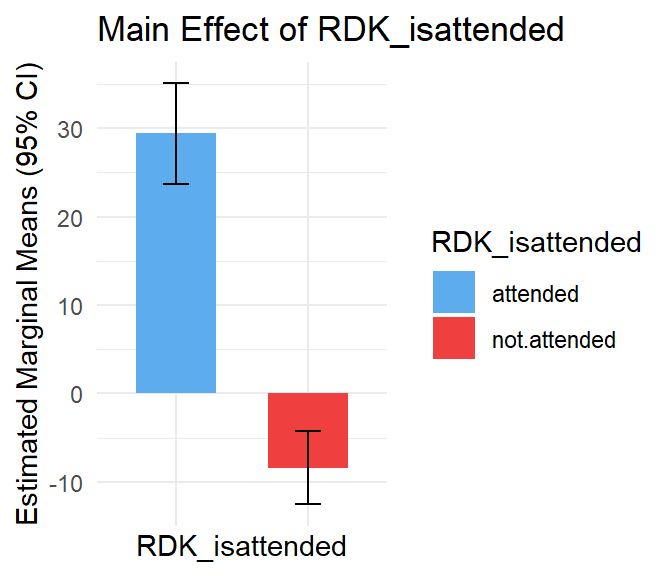

```r
#display main effects via emmeans
# Main effect of RDK_isattended
emm_ATT <- as.data.frame(emmeans(aovmodel2, ~ RDK_isattended))

# Main effect of condition_label
emm_Pericondition <- as.data.frame(emmeans(aovmodel2, ~ condition_label))

# RDK_isattended plot
ggplot(emm_ATT, aes(x = RDK_isattended, y = emmean, fill = RDK_isattended)) +
  geom_col(position = position_dodge(), width = 0.6) +
  geom_errorbar(aes(ymin = lower.CL, ymax = upper.CL), width = 0.2) +
  labs(title = "Main Effect of RDK_isattended",
       y = "Estimated Marginal Means (95% CI)", x = "RDK_isattended") +
  theme_minimal()+
  scale_fill_manual(values=c("steelblue2", "#F03F3F"))+
  scale_color_manual(values=c("steelblue2", "#F03F3F"))+
  theme(axis.text.x = element_blank())
```

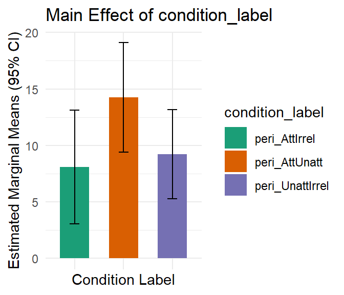

```r
# condition_label plot
ggplot(emm_Pericondition, aes(x = condition_label, y = emmean, fill = condition_label)) +
  geom_col(position = position_dodge(), width = 0.6) +
  geom_errorbar(aes(ymin = lower.CL, ymax = upper.CL), width = 0.2) +
  labs(title = "Main Effect of condition_label",
       y = "Estimated Marginal Means (95% CI)", x = "Condition Label") +
  theme_minimal()+
  scale_fill_brewer(palette = "Dark2")+
  scale_color_brewer(palette = "Dark2")+
  theme(axis.text.x = element_blank())
```

```r
#post hoc contrasts
post_hocs.RDK_isattended <- emmeans(aovmodel2, c("RDK_isattended"), contr = "pairwise",adjust = "FDR") # adjust = holm
post_hocs.condition_label <- emmeans(aovmodel2, c("condition_label"), contr = "pairwise",adjust = "FDR") # adjust = holm

# report data for post_hocs.RDK_isattended
post_hocs.RDK_isattended$emmeans %>%
  kbl(escape = F, digits = c(3,3,3,3,3,3,3,3,3), caption = c("estimated marginal means | by ATTENTION | dv = central SSVEP modulation")) %>%
  kable_styling("striped", full_width = T, bootstrap_options = c("striped", "hover", "condensed", "responsive",font_size = 8))
```

estimated marginal means | by ATTENTION | dv = central SSVEP modulation

| RDK_isattended | emmean | SE | df | lower.CL | upper.CL |
| --- | --- | --- | --- | --- | --- |
| attended | 29.424 | 2.784 | 29 | 23.730 | 35.117 |
| not.attended | -8.373 | 2.042 | 29 | -12.549 | -4.196 |

```r
summary(post_hocs.RDK_isattended$contrasts) %>%
  mutate(
    p.value = cell_spec(ifelse(round(p.value,4)<.001,"< .001",round(p.value,4)),
                        color = ifelse(is.nan(p.value),"blue", ifelse(p.value < .05, "green", "red")),
                        bold = ifelse(is.nan(p.value),F, ifelse(p.value < .05, T,F)),
                        align = "left")
  ) %>%
  # mutate(CohensD = `t.ratio`/sqrt(df+1))%>%
  mutate(`CohensD` =
           summary(eff_size(contrast(post_hocs.RDK_isattended, method = "pairwise", adjust = "FDR"),
                            sigma = sqrt(mean(sigma(aovmodel2$lm)^2)), # RMS of sigma()
                            edf = df.residual(aovmodel2$lm), method = "identity"))$effect.size,
         `lowCI` =
           summary(eff_size(contrast(post_hocs.RDK_isattended, method = "pairwise", adjust = "FDR"),
                            sigma = sqrt(mean(sigma(aovmodel2$lm)^2)), # RMS of sigma()
                            edf = df.residual(aovmodel2$lm), method = "identity"))$lower.CL,
         `highCI` =
           summary(eff_size(contrast(post_hocs.RDK_isattended, method = "pairwise", adjust = "FDR"),
                            sigma = sqrt(mean(sigma(aovmodel2$lm)^2)), # RMS of sigma()
                            edf = df.residual(aovmodel2$lm), method = "identity"))$upper.CL
  )%>%
  kbl(escape = F, digits = c(3,3,3,3,3,3,3,3,3),
        caption = c("contrasts for estimated marginal means |by ATTENTION | dv = central SSVEP modulation | corrected: FDR")) %>%
  kable_styling("striped", full_width = T, bootstrap_options = c("striped", "hover", "condensed", "responsive",font_size = 8))
```

contrasts for estimated marginal means |by ATTENTION | dv = central SSVEP modulation | corrected: FDR

| contrast | estimate | SE | df | t.ratio | p.value | CohensD | lowCI | highCI |
| --- | --- | --- | --- | --- | --- | --- | --- | --- |
| attended - not.attended | 37.796 | 3.347 | 29 | 11.294 | < .001 | 2.147 | 1.452 | 2.842 |

```r
# report data for post_hocs.condition_label
post_hocs.condition_label$emmeans %>%
  kbl(escape = F, digits = c(3,3,3,3,3,3,3,3,3), caption = c("estimated marginal means | by PERI_CON | dv = central SSVEP modulation")) %>%
  kable_styling("striped", full_width = T, bootstrap_options = c("striped", "hover", "condensed", "responsive",font_size = 8))
```

estimated marginal means | by PERI_CON | dv = central SSVEP modulation

| condition_label | emmean | SE | df | lower.CL | upper.CL |
| --- | --- | --- | --- | --- | --- |
| peri_AttIrrel | 8.084 | 2.452 | 29 | 3.070 | 13.098 |
| peri_AttUnatt | 14.260 | 2.372 | 29 | 9.408 | 19.111 |
| peri_UnattIrrel | 9.232 | 1.934 | 29 | 5.277 | 13.187 |

```r
summary(post_hocs.condition_label$contrasts) %>%
  mutate(
    p.value = cell_spec(ifelse(round(p.value,4)<.001,"< .001",round(p.value,4)),
                        color = ifelse(is.nan(p.value),"blue", ifelse(p.value < .05, "green", "red")),
                        bold = ifelse(is.nan(p.value),F, ifelse(p.value < .05, T,F)),
                        align = "left")
  ) %>%
  # mutate(CohensD = `t.ratio`/sqrt(df+1))%>%
  mutate(`CohensD` =
           summary(eff_size(contrast(post_hocs.condition_label, method = "pairwise", adjust = "FDR"),
                            sigma = sqrt(mean(sigma(aovmodel2$lm)^2)), # RMS of sigma()
                            edf = df.residual(aovmodel2$lm), method = "identity"))$effect.size,
         `lowCI` =
           summary(eff_size(contrast(post_hocs.condition_label, method = "pairwise", adjust = "FDR"),
                            sigma = sqrt(mean(sigma(aovmodel2$lm)^2)), # RMS of sigma()
                            edf = df.residual(aovmodel2$lm), method = "identity"))$lower.CL,
         `highCI` =
           summary(eff_size(contrast(post_hocs.condition_label, method = "pairwise", adjust = "FDR"),
                            sigma = sqrt(mean(sigma(aovmodel2$lm)^2)), # RMS of sigma()
                            edf = df.residual(aovmodel2$lm), method = "identity"))$upper.CL
  )%>%
  kbl(escape = F, digits = c(3,3,3,3,3,3,3,3,3),
        caption = c("contrasts for estimated marginal means |by PERI CON | dv = central SSVEP modulation | corrected: FDR")) %>%
  kable_styling("striped", full_width = T, bootstrap_options = c("striped", "hover", "condensed", "responsive",font_size = 8))
```

contrasts for estimated marginal means |by PERI CON | dv = central SSVEP modulation | corrected: FDR

| contrast | estimate | SE | df | t.ratio | p.value | CohensD | lowCI | highCI |
| --- | --- | --- | --- | --- | --- | --- | --- | --- |
| peri_AttIrrel - peri_AttUnatt | -6.176 | 2.841 | 29 | -2.174 | 0.057 | -0.351 | -0.694 | -0.008 |
| peri_AttIrrel - peri_UnattIrrel | -1.148 | 2.469 | 29 | -0.465 | 0.6454 | -0.065 | -0.353 | 0.222 |
| peri_AttUnatt - peri_UnattIrrel | 5.027 | 1.878 | 29 | 2.677 | 0.0363 | 0.286 | 0.054 | 0.517 |

```r
# pairs(emmeans(aovmodel2, ~ RDK_isattended))
# pairs(emmeans(aovmodel2, ~ condition_label))
```